# Coursework Report, 218075

*N* removed NAs: 3

*N* removed typo: 1

*N* removed <18: 11

*N* total clean: 135

| Group | *N* | *M*<sub>age</sub> | *M*<sub>rating</sub> |
| --- | --- | --- | --- |
| Control | 70 | 21.10 | 5.65 |
| Experim | 65 | 21.12 | 6.33 |

**Main analysis results**

*t*(133) = -4.83, *p* < .001

[interactive chart not shown]

[figure not shown]

[interactive chart not shown]

# Coursework Report, 218075

Analysing Data, Spring 2020

# Methods

## Participants

In this experiment we studied how colour affects women’s attraction to men, therefore all the participants of this study were female. The data of 135 undergraduate female students (*M*<sub>age</sub> = 21.11, *SD*<sub>age</sub> = 1.7), who did not have colour blindness, were collected in the study via a lab experiment which they participated in voluntarily, or for course credits.This excludes 11 participants who were excluded due to unlikely values of age, in addition to data from 3 participants which were also excluded as they did not disclose their age,to avoid using data from a minor. Data from 1 participant was also excluded as their age was not clearly filled out.

## Design

The hypothesis tested was, does colour affect attractiveness? Therefore in the experiment we compared whether a man with a white background or a red background is more attractive to the female participants. Each participant had a personal ID ,a factor, to ensure anonymity and confidentiality in the data. There was a condition factor (the independent variable) which had two levels, a control group and an experimental group. The control group were presented with a black and white photo of a man on a white background and the experimental group viewed a black and white photo of a man on a red background. We compared the results of the two groups to understand whether the null hypothesis or the alternative hypothesis was true. The null hypothesis is: colour does not affect attractiveness. The alternative hypothesis is: colour does affect attractiveness. To measure attractiveness the participants had to rate attractiveness by answering 3 questions. 1)“How attractive do you think this person is?”, 2)“How pleasant is this person to look at?” and 3)“If I were to meet the person in this picture face to face, I would think he is attractive”. They answered the questions using a rating of 1-9, 1 is “not at all attrective” and 9 is “extremely attractive”, then a composite score for each question was calculated. I predicted that this study will show that red will have a higher mean rating than white, therefore red makes men more attractive to women. I will check if this is the case using an independent *t*-test.

# Results

We investigated whether red affects attractvieness ratings. The red group had a mean attractiveness score of 6.33, whereas the white group had a mean attractiveness score of 5.65. We investigated whether, as predicted, peope would rate attracvtiveness differently depending on the colour condition they are in using an independent *t*-test. This test showed that the means in the two condiitons were significantly different (*M*<sub>diff</sub> = 0.69, 95% CI [-0.41, -0.97]) and there is a significant differnece between the two groups on the rating of attractiveness (*t* (133) = -4.83, *p* = < .001).This suggests that there is a significant difference between the two conditions therefore the null hypothesis is incorrect and red does affect attractiveness rating. Therefore colour does affect attractiveness.

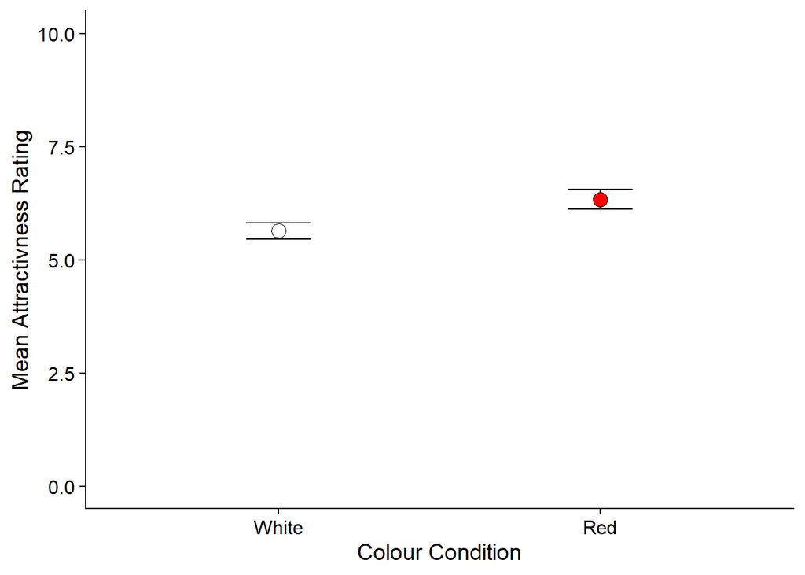

Figure 1. Mean attractiveness rating by colour condition

# Discussion

Overall the results suggest that red does affect attractiveness as the red group’s mean attractiveness rating was higher than the white group’s. In the original study the results also established that colour influences attractiveness (Elliot et al., 2010). This suggests that the original investigation is reliable and repeatable, this increases my confidence in the results and suggests that the hypothesis that colour affects attractiveness is true.

There has been otehr data supportingthe hypotheiss that red affects attractiveness.Elliot et al conducted a study in 2008 suggesting that women received higher ratings on attractiveness and other factors if they were wearing a red shirt instead of a blue one (Elliot & Niesta, 2008). It was also found that when men were presented with a picture of a woman in different coloured shirts, the highest attractiveness rating was given when she was in a red shirt, suggesting that red does affect attractiveness (Guéguen, 2012). A study conducted with Chinese students found that red does increase the attractiveness ratings for women with feminine features but not those with masculine features, suggesting that the red effect (red increasing attractiveness) occurs across cultures but only for certain women (Wen et al., 2014). Gueguen et al (2014) found in a field study that red increased mean’s tipping for women, suggesting that there is a red effect (Guéguen & Jacob, 2014). However, Lynn et al conducted a replication via an online experiment using hypothetical tipping and found that red did not have the highest attractiveness rate (Lynn et al., 2016).

There have been more replication studies which suggest that the red effect does not occur. Peperkoorn et al replicated Elliot et al (2012) study with Dutch participants and found that a white effect occurred, the attractiveness ratings were the highest for white not for red (Peperkoorn et al., 2016), which is inconsistent with the results found in our replication of Elliot et al (2010). They then conducted the same study but with American participants and also found that the red effect did not occur and red did not have a higher attractiveness rating(Peperkoorn et al., 2016). To try and definitely determine whether the red effect occurs Peoerkoorn et al the replicated Pazda et al (2012) study and again established that red did not have a higher attractiveness rating than white.

The most recent data suggests that red does not affect attractiveness, as many have replicated the original Elliot et al studies and either show that the red effect partly works (only for feminine features), or that the effect does not occur altogether. This suggests that maybe the effect is not that reliable because with a larger sample and in different cultures it did not occur, however not many replications have been done, and most of the replications were done by the same researchers which could increase researcher bias or online and not in real life. Therefore more replications should be conducted by different researchers to definitely understand whether the red effect does occur. Also a replication of Gueguen et al’s (2014) study should be conducted however not online to see wether the red effect does occur, and to allow the results to be comparable, as the environment where the ratings were made could affect the rating level.

A strength of our replication is that it is an independent measures design therefore there is no order effect as the participants do not need to be in both conditions. This also reduces demand characteristics as the participants only participate in one condition. The participants were randomly allocated increasing the reliability of the data.In addition, all participants were given an ID code to maintian anonimity which icreases the confidentiality of the esperiment. A limitation of the study is that different age groups were not considered in this study as only undergraduate students were used, it would be interesting to see if the red effect is present for older age groups. Also undergraduate students were used so they could have predicted the hypothesis that was being tested. Most of the research conducted has been done on how women are more attracted to men, therefore future research could be done on whether red increases attractiveness ratings in homosexual couples, this could also be interesting as this links to whether the red effect is an evolutionary effect or not.

In closing, the results show that the red effect is real and red does affect attractiveness ratings because the red groups mean was higher, even though there have been other replications that suggest otherwise. However more research needs to be done to investigate the effect further, including further replications made by other researchers and with homosexual couples and with different age groups.

# References

Elliot, A. J., & Maier, M. A. (2012). Color-in-Context Theory. In Advances in Experimental Social Psychology (Vol. 45, pp. 61–125). Elsevier. https://doi.org/10.1016/B978-0-12-394286-9.00002-0

Elliot, A. J., & Niesta, D. (2008). Romantic red: Red enhances men’s attraction to women. Journal of Personality and Social Psychology, 95(5), 1150–1164. https://doi.org/10.1037/0022-3514.95.5.1150

Elliot, A. J., Niesta Kayser, D., Greitemeyer, T., Lichtenfeld, S., Gramzow, R. H., Maier, M. A., & Liu, H. (2010). Red, rank, and romance in women viewing men. Journal of Experimental Psychology: General, 139(3), 399–417. https://doi.org/10.1037/a0019689

Guéguen, N. (2012). Color and Women Attractiveness: When Red Clothed Women Are Perceived to Have More Intense Sexual Intent. The Journal of Social Psychology, 152(3), 261–265. https://doi.org/10.1080/00224545.2011.605398

Guéguen, N., & Jacob, C. (2014). Clothing Color and Tipping: Gentlemen Patrons Give More Tips to Waitresses with Red Clothes. Journal of Hospitality & Tourism Research, 38(2), 275–280. https://doi.org/10.1177/1096348012442546

Lynn, M., Giebelhausen, M., Garcia, S., Li, Y., & Patumanon, I. (2016). Clothing Color and Tipping: An Attempted Replication and Extension. Journal of Hospitality & Tourism Research, 40(4), 516–524. https://doi.org/10.1177/1096348013504001

Pazda, A. D., Elliot, A. J., & Greitemeyer, T. (2012). Sexy red: Perceived sexual receptivity mediates the red-attraction relation in men viewing woman. Journal of Experimental Social Psychology, 48(3), 787–790. https://doi.org/10.1016/j.jesp.2011.12.009

Peperkoorn, L. S., Roberts, S. C., & Pollet, T. V. (2016). Revisiting the Red Effect on Attractiveness and Sexual Receptivity: No Effect of the Color Red on Human Mate Preferences. Evolutionary Psychology, 14(4), 147470491667384. https://doi.org/10.1177/1474704916673841

Wen, F., Zuo, B., Wu, Y., Sun, S., & Liu, K. (2014). Red is Romantic, but Only for Feminine Females: Sexual Dimorphism Moderates Red Effect on Sexual Attraction. Evolutionary Psychology, 12(4), 147470491401200. https://doi.org/10.1177/147470491401200404